# Panel Data NLSY97

Christine Lucille Kuryla

2024-11-16

This analysis uses panel data from NLSY97 (National Longitudinal Survey Youth 1997). More information and data can be found here: https://www.bls.gov/nls/nlsy97.htm

Outcome variable: `health` Our outcome variable of interest is self-rated health. In this dataset, the variable has been recoded and named health and ranges from 1 (Poor) to 5 (Excellent) as detailed below.

Main predictor: `watched_tv` Our main predictor variable of interest is how often the participant watches TV. The interpretation ranges from 1 (No TV) to 6 (10+ hours per week). The values are described below. - “None” - “Less than 1 hour a week” - “1 to 3 hours a week” - “4 to 6 hours a week” - “7 to 9 hours a week” - “10 hours or more a week”

Other predictor: `felt_happy` How often the respondent felt happy in the last month. This variable has been recoded such that it ranges from: - “All of the time” - “Most of the time” - “Some of the time” - “None of the time”

Other predictor: `depressed` How often the respondent was depressed in the last month. This variable has been recoded such that it ranges from: - “All of the time” - “Most of the time” - “Some of the time” - “None of the time”

# Variables of interest description

How would you rate your health?

(Note these have been recoded)

5 - “Excellent”

4 - “Very good”

3 - “Good”

2 - “Fair”

1 - “Poor”

How often felt happy in the last month:

How often felt down or blue in the last month:

How often felt calm in the last month:

How often felt like a nervous person in the last month:

How often felt depressed in the last month:

(Note these have been recoded from original data)

4 - “All of the time”

3 - “Most of the time”

2 - “Some of the time”

1 - “None of the time”

Watches TV

1 - “None”

2 - “Less than 1 hour a week”

3 - “1 to 3 hours a week”

4 - “4 to 6 hours a week”

5 - “7 to 9 hours a week”

6 - “10 hours or more a week”

Uses computer

1 - “Less than 2 hours per week”

2 - “3 to 10 hours a week”

3 - “11 to 20 hours a week”

4 - “21 to 30 hours a week”

5 - “31 to 40 hours a week”

6 - “More than 40 hours a week”

# Load and explore data

```r
data <- read_csv("data/panel/nlsy97_selected.csv")  %>%
  filter(year != 2008) # there were not enough observations in this wave
# Number of participants

data %>%
  pull(id) %>%
  unique %>%
  length()
```

```
## [1] 8522
```

```r
# Number of waves

data %>%
  pull(year) %>%
  unique()
```

```
## [1] 2002 2010 2015 2017
```

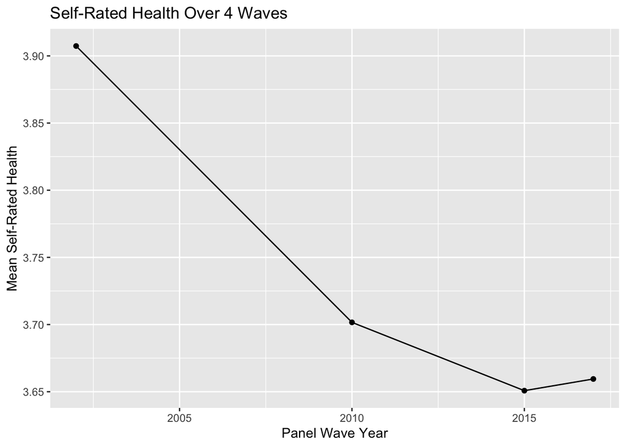

```r
data %>%
  group_by(year) %>%
  summarize(mean_srh = mean(health)) %>%
  ggplot(aes(x = year, y = mean_srh)) +
  geom_line() +
  geom_point() +
  labs(title = "Self-Rated Health Over 4 Waves",
       x = "Panel Wave Year",
       y = "Mean Self-Rated Health")
```

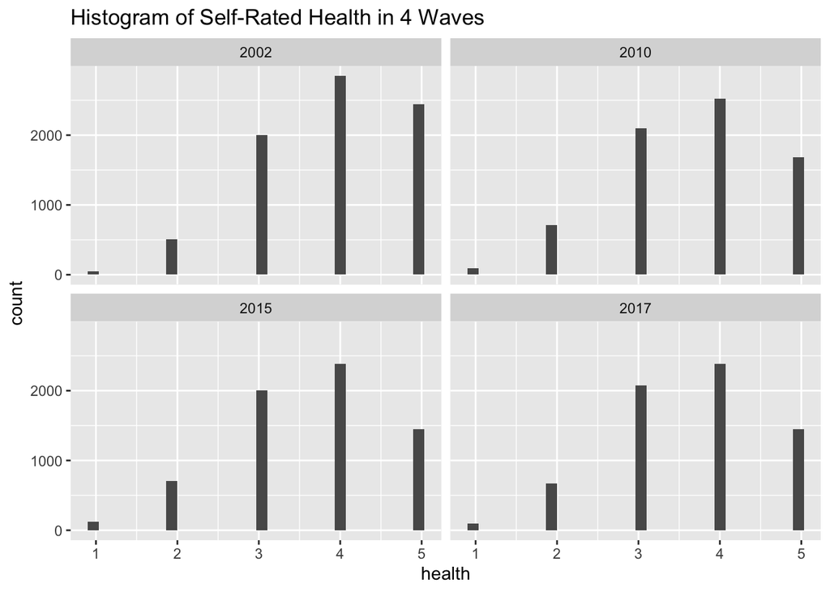

```r
data %>%
  group_by(year) %>%
  ggplot(aes(x = health)) +
  geom_histogram() +
  facet_wrap(~ year) +
  labs(title = "Histogram of Self-Rated Health in 4 Waves")
```

```r
data <- data %>%
  filter(year != 2008)
```

# a) OLS

1. 1. Run an OLS regression, including at least one independent variable and a time variable (as dummies). Explain how you think your independent variable relates to your dependent variable. Interpret your results. Did you find what you expected to find?

```r
library(plm)
# OLS regression
summary(lm(health ~ watched_tv + as.factor(year), data))
```

```
##
## Call:
## lm(formula = health ~ watched_tv + as.factor(year), data = data)
##
## Residuals:
##     Min      1Q  Median      3Q     Max
## -3.0175 -0.6752  0.2521  0.6157  1.6203
##
## Coefficients:
##                     Estimate Std. Error t value Pr(>|t|)
## (Intercept)          4.09016    0.01682  243.12   <2e-16 ***
## watched_tv          -0.07271    0.00510  -14.26   <2e-16 ***
## as.factor(year)2010 -0.21526    0.01582  -13.61   <2e-16 ***
## as.factor(year)2015 -0.27425    0.01612  -17.02   <2e-16 ***
## as.factor(year)2017 -0.26960    0.01613  -16.71   <2e-16 ***
## ---
## Signif. codes:  0 '***' 0.001 '**' 0.01 '*' 0.05 '.' 0.1 ' ' 1
##
## Residual standard error: 0.9654 on 28316 degrees of freedom
## Multiple R-squared:  0.01918,    Adjusted R-squared:  0.01904
## F-statistic: 138.4 on 4 and 28316 DF,  p-value: < 2.2e-16
```

```r
eq.pool_tv <- plm(health ~ watched_tv + as.factor(year), # model formula
               index = c("id", "year"), # id & time variables
               model = "pooling",
               data = data) ## this is equivalent to above OLS ##

summary(eq.pool_tv)
```

```
## Pooling Model
##
## Call:
## plm(formula = health ~ watched_tv + as.factor(year), data = data,
##     model = "pooling", index = c("id", "year"))
##
## Unbalanced Panel: n = 8522, T = 1-4, N = 28321
##
## Residuals:
##     Min.  1st Qu.   Median  3rd Qu.     Max.
## -3.01745 -0.67515  0.25215  0.61568  1.62032
##
## Coefficients:
##                       Estimate Std. Error t-value  Pr(>|t|)
## (Intercept)          4.0901589  0.0168240 243.115 < 2.2e-16 ***
## watched_tv          -0.0727059  0.0050998 -14.257 < 2.2e-16 ***
## as.factor(year)2010 -0.2152578  0.0158203 -13.607 < 2.2e-16 ***
## as.factor(year)2015 -0.2742455  0.0161173 -17.016 < 2.2e-16 ***
## as.factor(year)2017 -0.2696017  0.0161339 -16.710 < 2.2e-16 ***
## ---
## Signif. codes:  0 '***' 0.001 '**' 0.01 '*' 0.05 '.' 0.1 ' ' 1
##
## Total Sum of Squares:    26905
## Residual Sum of Squares: 26389
## R-Squared:      0.019182
## Adj. R-Squared: 0.019043
## F-statistic: 138.442 on 4 and 28316 DF, p-value: < 2.22e-16
```

# b) Fixed Effects

2. Then run a fixed effect model version of that OLS model. Interpret your results. Did you find what you expected to find? Why? Why not?

```r
eq.fe_tv <- plm(health ~ watched_tv + as.factor(year), # model formula
             index = c("id", "year"), # id & time variables
             model = "within",
             data = data) ## fixed effects ##

summary(eq.fe_tv)
```

```
## Oneway (individual) effect Within Model
##
## Call:
## plm(formula = health ~ watched_tv + as.factor(year), data = data,
##     model = "within", index = c("id", "year"))
##
## Unbalanced Panel: n = 8522, T = 1-4, N = 28321
##
## Residuals:
##      Min.   1st Qu.    Median   3rd Qu.      Max.
## -3.179599 -0.411371  0.032358  0.332208  2.579249
##
## Coefficients:
##                       Estimate Std. Error  t-value Pr(>|t|)
## watched_tv          -0.0117978  0.0055235  -2.1359   0.0327 *
## as.factor(year)2010 -0.2031087  0.0122910 -16.5250   <2e-16 ***
## as.factor(year)2015 -0.2588579  0.0126268 -20.5007   <2e-16 ***
## as.factor(year)2017 -0.2446321  0.0126634 -19.3180   <2e-16 ***
## ---
## Signif. codes:  0 '***' 0.001 '**' 0.01 '*' 0.05 '.' 0.1 ' ' 1
##
## Total Sum of Squares:    10616
## Residual Sum of Squares: 10327
## R-Squared:      0.027237
## Adj. R-Squared: -0.3917
## F-statistic: 138.565 on 4 and 19795 DF, p-value: < 2.22e-16
```

# Additional predictor

3. Then include an additional predictor in your fixed effects model that you think might account for the initial relationship you found between your X and your Y. What effect does that new independent variable have in your new regression?

```r
eq.fe_tv_happy <- plm(health ~ watched_tv + felt_happy + as.factor(year), # model formula
             index = c("id", "year"), # id & time variables
             model = "within",
             data = data) ## fixed effects ##

summary(eq.fe_tv_happy)
```

```
## Oneway (individual) effect Within Model
##
## Call:
## plm(formula = health ~ watched_tv + felt_happy + as.factor(year),
##     data = data, model = "within", index = c("id", "year"))
##
## Unbalanced Panel: n = 8522, T = 1-4, N = 28321
##
## Residuals:
##       Min.    1st Qu.     Median    3rd Qu.       Max.
## -2.9647059 -0.3576620  0.0084701  0.3598396  2.6141212
##
## Coefficients:
##                       Estimate Std. Error  t-value Pr(>|t|)
## watched_tv          -0.0083380  0.0054739  -1.5232   0.1277
## felt_happy           0.1774265  0.0090731  19.5553   <2e-16 ***
## as.factor(year)2010 -0.2022548  0.0121744 -16.6132   <2e-16 ***
## as.factor(year)2015 -0.2633805  0.0125090 -21.0553   <2e-16 ***
## as.factor(year)2017 -0.2719827  0.0126209 -21.5502   <2e-16 ***
## ---
## Signif. codes:  0 '***' 0.001 '**' 0.01 '*' 0.05 '.' 0.1 ' ' 1
##
## Total Sum of Squares:    10616
## Residual Sum of Squares: 10131
## R-Squared:      0.045675
## Adj. R-Squared: -0.36539
## F-statistic: 189.47 on 5 and 19794 DF, p-value: < 2.22e-16
```

# d) Random Effects

4. Then run a random effects model equivalent to your fixed effects model in step (b). Interpret the results.

```r
eq.re_tv <- plm(health ~ watched_tv + as.factor(year), # model formula
             index = c("id", "year"), # id & time variables
             model = "random",
             data = data) ## random effects ##

summary(eq.re_tv)
```

```
## Oneway (individual) effect Random Effect Model
##    (Swamy-Arora's transformation)
##
## Call:
## plm(formula = health ~ watched_tv + as.factor(year), data = data,
##     model = "random", index = c("id", "year"))
##
## Unbalanced Panel: n = 8522, T = 1-4, N = 28321
##
## Effects:
##                  var std.dev share
## idiosyncratic 0.5217  0.7223 0.562
## individual    0.4061  0.6372 0.438
## theta:
##    Min. 1st Qu.  Median    Mean 3rd Qu.    Max.
##  0.2501  0.4524  0.5069  0.4822  0.5069  0.5069
##
## Residuals:
##     Min.  1st Qu.   Median     Mean  3rd Qu.     Max.
## -3.06307 -0.51673  0.06367 -0.00125  0.56580  1.96290
##
## Coefficients:
##                       Estimate Std. Error  z-value  Pr(>|z|)
## (Intercept)          4.0061048  0.0162329 246.7898 < 2.2e-16 ***
## watched_tv          -0.0380084  0.0048279  -7.8727 3.471e-15 ***
## as.factor(year)2010 -0.2093777  0.0120850 -17.3255 < 2.2e-16 ***
## as.factor(year)2015 -0.2662973  0.0123793 -21.5115 < 2.2e-16 ***
## as.factor(year)2017 -0.2559101  0.0124042 -20.6309 < 2.2e-16 ***
## ---
## Signif. codes:  0 '***' 0.001 '**' 0.01 '*' 0.05 '.' 0.1 ' ' 1
##
## Total Sum of Squares:    16577
## Residual Sum of Squares: 14809
## R-Squared:      0.1068
## Adj. R-Squared: 0.10668
## Chisq: 648.065 on 4 DF, p-value: < 2.22e-16
```

# e) Hausman test

5. Run a Hausman test to compare your fixed effects and your random effects models. What do you conclude?

```r
library(stargazer)
phtest(eq.fe_tv, eq.re_tv) ## Hausman test comparing RE and FE ##
```

```
##
##  Hausman Test
##
## data:  health ~ watched_tv + as.factor(year)
## chisq = 97.843, df = 4, p-value < 2.2e-16
## alternative hypothesis: one model is inconsistent
```

```r
stargazer(eq.pool_tv, eq.fe_tv, eq.re_tv,
          title="Regression Results",
          align=TRUE,
          dep.var.labels=c("Equalize"),
       #   covariate.labels=c("Bills","2010"),
          no.space=TRUE,
          column.labels=c("Pooled",
                        #  "First Diff",
                          "Fixed Effects", "Random Effects"),
          dep.var.caption="",
          model.numbers=FALSE,
          type = "text", omit = "Constant")
```

```
##
## Regression Results
## ========================================================================================
##                                                   Equalize
##                               Pooled                 Fixed Effects        Random Effects
## ----------------------------------------------------------------------------------------
## watched_tv                  -0.073***                   -0.012**            -0.038***
##                              (0.005)                    (0.006)              (0.005)
## as.factor(year)2010         -0.215***                  -0.203***            -0.209***
##                              (0.016)                    (0.012)              (0.012)
## as.factor(year)2015         -0.274***                  -0.259***            -0.266***
##                              (0.016)                    (0.013)              (0.012)
## as.factor(year)2017         -0.270***                  -0.245***            -0.256***
##                              (0.016)                    (0.013)              (0.012)
## ----------------------------------------------------------------------------------------
## Observations                  28,321                     28,321               28,321
## R2                            0.019                      0.027                0.107
## Adjusted R2                   0.019                      -0.392               0.107
## F Statistic         138.442*** (df = 4; 28316) 138.565*** (df = 4; 19795)   648.065***
## ========================================================================================
## Note:                                                        *p<0.1; **p<0.05; ***p<0.01
```